# Exercise 03: Data for Environmental Sciences

Chenwei Xiao

10/04/2020

## Using Spatial Data

### Part 1: Plotting Elevation differences

In this first part of the exercise, we consider elevation data from the ETOPO dataset. ETOPO is a 1 arc-minute(0.016 degree) global relief model of the Earth’s surface that integrates land topography and ocean bathymetry. Since it is modelled date there is a certain level of uncertainty associated with it. In this exercise, you will look at the differences between the elevations from the tower data, which is directly measured at the site, and the values you will extract from this modelled ETOPO data.

*Note:* think about which packages you need to load to complete each of the tasks.

1. Load the *‘dataset_ex3.csv’* file containing the elevations of the towers.

```r
# enter your solution here
library(tidyverse)
ele_towers <- read_csv("../../data/data_exercise_03/dataset_ex3.csv")
colnames(ele_towers)[1] <- 'ID'
ele_towers %>% head()
```

```
## # A tibble: 6 x 6
##      ID sitename longitude latitude elevation temperature
##   <dbl> <chr>        <dbl>    <dbl>     <dbl>       <dbl>
## 1     1 BE-Bra        4.52     51.3        16        4.59
## 2     2 BE-Lon        4.75     50.6       167        1.01
## 3     3 BE-Vie        6.00     50.3       493       -1.38
## 4     4 CH-Cha        8.41     47.2       393       -2.33
## 5     5 CH-Dav        9.86     46.8      1639       -4.96
## 6     6 CH-Fru        8.54     47.1       982       -2.53
```

2. Load both the *‘ETOPO.tif’* raster and the *‘europe_shape’* shapefile. Plot the shape of Europe over the raster. (Since we used the shapefile in the tutorial too, it isn’t located in the same folder as the data for this exercise. You’ll have to use the correct pathway to load it, if you are unsure about how to find this use the ‘Files’ tab on the right can help you figure it out.)

```r
# enter your solution here
library(raster)
library(rasterVis)
library(sf)
library(spData)
library(sp)
library(rgdal)
raster_ETOPO <- raster("../../data/data_exercise_03/ETOPO.tif")
europe_shape <- readOGR(dsn="../../data/shapefiles", layer="europe_map")
```

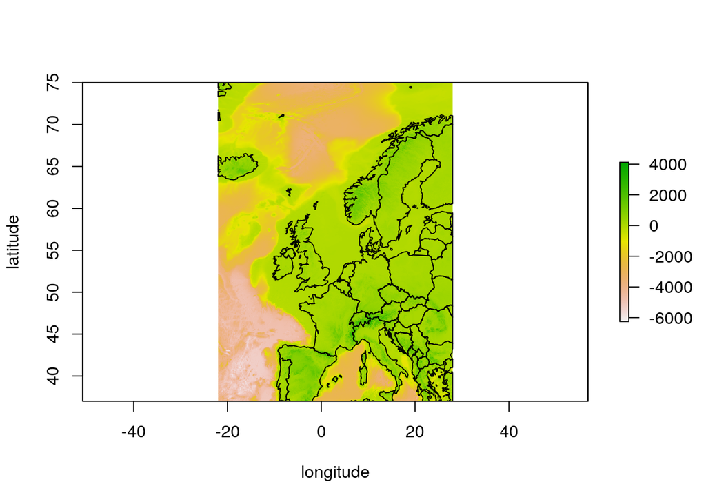

```r
projection(raster_ETOPO) <- europe_shape@proj4string
plot(raster_ETOPO,xlab="longitude", ylab="latitude");plot(europe_shape, add=TRUE)
```

3. Extract the elevations from the raster at the tower sites.

```r
# enter your solution here
## generate the sp locations of towers
sp_sites <- SpatialPoints(dplyr::select(ele_towers, longitude, latitude))
## extract from the raster and join into original tower data
ele_towers_joined <- extract(raster_ETOPO, sp_sites, sp = TRUE) %>%
  as_tibble() %>%
  right_join(ele_towers, by = c("longitude", "latitude")) %>%
  dplyr::rename(ele_ETOPO = ETOPO)
## new joined data
ele_towers_joined %>% head()
```

```
## # A tibble: 6 x 7
##   ele_ETOPO longitude latitude    ID sitename elevation temperature
##       <dbl>     <dbl>    <dbl> <dbl> <chr>        <dbl>       <dbl>
## 1        19      4.52     51.3     1 BE-Bra          16        4.59
## 2       161      4.75     50.6     2 BE-Lon         167        1.01
## 3       499      6.00     50.3     3 BE-Vie         493       -1.38
## 4       394      8.41     47.2     4 CH-Cha         393       -2.33
## 5      1704      9.86     46.8     5 CH-Dav        1639       -4.96
## 6       983      8.54     47.1     6 CH-Fru         982       -2.53
```

4. Calculate the difference between the elevations of the towers and the one extracted from the ETOPO.

```r
# enter your solution here
library(Metrics)
## use the MSE to measure the difference
cat("The MSE of two elevations is", mse(ele_towers_joined$ele_ETOPO, ele_towers_joined$elevation))
```

```
## The MSE of two elevations is 3262.667
```

5. Plot the difference in elevation calculated for each site on a map of Europe. *Hint:* there are several ways to do this, one could be to using ifelse().

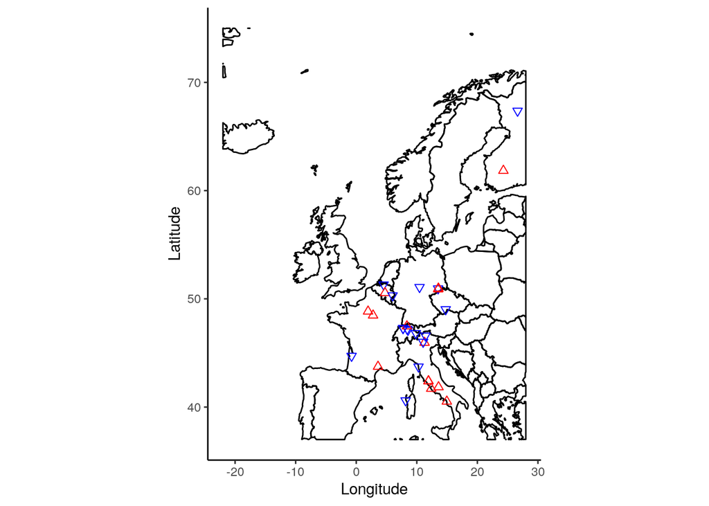

```r
# enter your solution here
ele_towers_joined<-ele_towers_joined %>%
  mutate(ele_diff = elevation - ele_ETOPO)

## plot the difference so that if ele_diff > 0, then the symbol is upper red, or down blue.
cols_ele_diff <- ifelse(ele_towers_joined$ele_diff > 0,"red","blue")
pch_ele_diff <- ifelse(ele_towers_joined$ele_diff > 0, 24 , 25)

ggplot() +
  geom_polygon(data = europe_shape, aes(x = long, y = lat, group = group), fill=NA, colour = "black") +
  geom_point(data = ele_towers_joined, aes(x = longitude, y = latitude),color=cols_ele_diff, pch = pch_ele_diff, size=2) +
  labs(x = "Longitude", y = "Latitude") +
  theme_classic()+
  coord_quickmap()
```

## Part 2: Temperature and Elevation Correlations

In this second part, we want to find out which of the elevations we gathered in the first part (ETOPO and towers) correlates better with the temperatures measured at the towers.

1. Correlate the ETOPO elevations at the towers sites with the temperatures measured at the towers.

```r
# enter your solution here
## do the pearson correlation test
cor.test(ele_towers_joined$ele_ETOPO, ele_towers_joined$temperature)
```

```
##
##  Pearson's product-moment correlation
##
## data:  ele_towers_joined$ele_ETOPO and ele_towers_joined$temperature
## t = -2.9946, df = 28, p-value = 0.005693
## alternative hypothesis: true correlation is not equal to 0
## 95 percent confidence interval:
##  -0.7242793 -0.1607900
## sample estimates:
##        cor
## -0.4925282
```

```r
## do the linear regression
reg1 <- lm(temperature ~ ele_ETOPO, data = ele_towers_joined)
summary(reg1)
```

```
##
## Call:
## lm(formula = temperature ~ ele_ETOPO, data = ele_towers_joined)
##
## Residuals:
##      Min       1Q   Median       3Q      Max
## -11.5371  -3.2284   0.7566   2.9479   7.1683
##
## Coefficients:
##              Estimate Std. Error t value Pr(>|t|)
## (Intercept)  1.725103   1.082327   1.594  0.12219
## ele_ETOPO   -0.004330   0.001446  -2.995  0.00569 **
## ---
## Signif. codes:  0 '***' 0.001 '**' 0.01 '*' 0.05 '.' 0.1 ' ' 1
##
## Residual standard error: 4.35 on 28 degrees of freedom
## Multiple R-squared:  0.2426, Adjusted R-squared:  0.2155
## F-statistic: 8.968 on 1 and 28 DF,  p-value: 0.005693
```

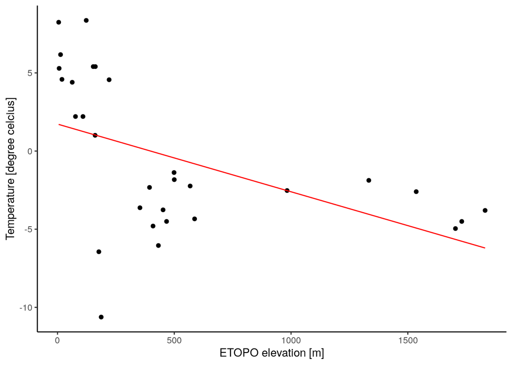

```r
## plot the relationship
ele_towers_joined %>%
  ggplot(aes(x = ele_ETOPO, y = temperature)) +
  geom_point() +
  geom_smooth(method='lm', color="red", size=0.5, se=FALSE) +
  xlab("ETOPO elevation [m]") +
  ylab("Temperature [degree celcius]") +
  theme_classic()
```

2. Correlate the elevations measured at the tower sites with the temperatures measured at the towers.

```r
# enter your solution here
## do the same operation as above for elevation at towers
## do the pearson correlation test
cor.test(ele_towers_joined$elevation, ele_towers_joined$temperature)
```

```
##
##  Pearson's product-moment correlation
##
## data:  ele_towers_joined$elevation and ele_towers_joined$temperature
## t = -2.9957, df = 28, p-value = 0.005677
## alternative hypothesis: true correlation is not equal to 0
## 95 percent confidence interval:
##  -0.7243645 -0.1609645
## sample estimates:
##        cor
## -0.4926639
```

```r
## do the linear regression
reg2 <- lm(temperature ~ elevation, data = ele_towers_joined)
summary(reg2)
```

```
##
## Call:
## lm(formula = temperature ~ elevation, data = ele_towers_joined)
##
## Residuals:
##      Min       1Q   Median       3Q      Max
## -11.5978  -2.8390   0.7094   2.8810   6.6952
##
## Coefficients:
##              Estimate Std. Error t value Pr(>|t|)
## (Intercept)  1.792569   1.097517   1.633  0.11360
## elevation   -0.004536   0.001514  -2.996  0.00568 **
## ---
## Signif. codes:  0 '***' 0.001 '**' 0.01 '*' 0.05 '.' 0.1 ' ' 1
##
## Residual standard error: 4.349 on 28 degrees of freedom
## Multiple R-squared:  0.2427, Adjusted R-squared:  0.2157
## F-statistic: 8.974 on 1 and 28 DF,  p-value: 0.005677
```

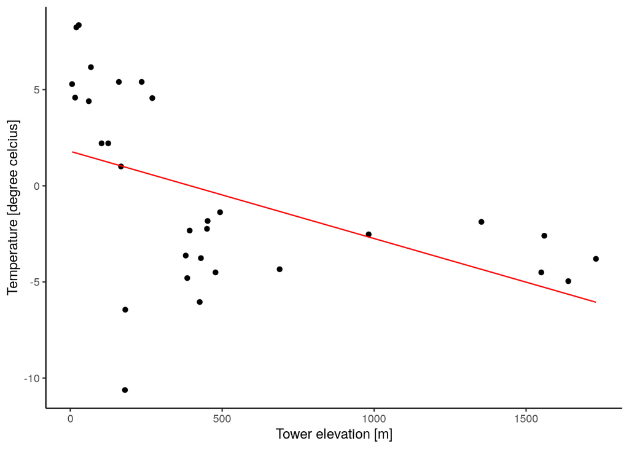

```r
## plot the relationship
ele_towers_joined %>%
  ggplot(aes(x = elevation, y = temperature)) +
  geom_point() +
  geom_smooth(method='lm', color="red", size=0.5, se=FALSE) +
  xlab("Tower elevation [m]") +
  ylab("Temperature [degree celcius]") +
  theme_classic()
```

3. What is the mean squared errors of the two models above. Which of the two correlates better?

```r
# enter your solution here
mse1 <- mean(reg1$residuals^2)
mse2 <- mean(reg2$residuals^2)
cat("MSE of the first model is",mse1,'and','MSE of the second model is',mse2)
```

```
## MSE of the first model is 17.65813 and MSE of the second model is 17.65501
```

4. The *‘lapse rate’* is known as the rate of decrease of an atmospheric variable, in our case temperature, with increased elevation (also altitude). This *lapse* (gradual fall) in temperature with increasing altitude at a given time and place, is the slope of your models above. Find and compare the *lapse rate* of the two models. *Hint:* if you are stuck take a closer look at your model with summary().

```r
# enter your solution here
lapse_rate1 <- reg1$coefficients[2]
lapse_rate2 <- reg2$coefficients[2]
cat("Lapse rate of the first model is",lapse_rate1*100,'K/100m','and','lapse rate of the second model is',lapse_rate2*100,'K/100m.')
```

```
## Lapse rate of the first model is -0.4330472 K/100m and lapse rate of the second model is -0.4536285 K/100m.
```

Now, that you’ve made it to the end of the exercise, remember to ‘knit’ this document so you can upload the html to moodle.